```python
import pandas as pd
import matplotlib.pyplot as plt
from chinese_calendar import is_workday
import numpy as np
plt.rcParams['font.sans-serif'] = ['SimHei']  # 中文显示
plt.rcParams['axes.unicode_minus'] = False   # 符号显示
plt.style.use('ggplot')
import warnings
warnings.filterwarnings('ignore')
import re
from sklearn.ensemble import RandomForestRegressor
from sklearn.metrics import mean_absolute_error, mean_absolute_percentage_error, r2_score
import time
```

# 工单检修处理

## 1.1 检修时间

```python
with open('./data/附件3：工单_train.txt', encoding='GBK', mode='r') as f:
    gd = f.readlines()

# 提取时间写法不一致的数据
[i for i in gd if '点' in i or '分' in i or '时,' in i or '时，' in i or '日' in i or '年' in i ]
```

```
['计划维修测试：负责人：陈一仁， 时间：2018年01月30日22:15:00， 开关状态：半开\n',
 '计划维修测试：负责人：李省， 时间：2018年02月13日04:45:00， 开关状态：半开\n',
 '计划检修：负责人：梁亮， 时间：2018-02-14 11点， 开关状态：全开\n',
 '计划检修：负责人：张果力， 时间：2018-03-05 15点半， 开关状态：全开\n',
 '计划检修：负责人：梁亮， 时间：2018-03-19 10点半， 开关状态：全开\n',
 '计划检修：负责人：李省， 时间：2018-04-15 11点， 开关状态：全开\n',
 '计划检修：负责人：梁亮， 时间：2018-05-23 11点15， 开关状态：全开\n',
 '计划检修：负责人：梁亮， 时间：2018-06-17 17点15， 开关状态：全开\n',
 '计划检修：负责人：李省， 时间：2018-08-01 09点， 开关状态：全开\n',
 '计划维修测试：负责人：李省， 时间：2018-09-09 03点， 开关状态：半开\n',
 '计划维修测试：负责人：陈一仁， 时间：2020年02月09日11点半， 开关状态：半开\n',
 '计划维修测试：负责人：张果力， 时间：2020年07月31日19点45分， 开关状态：半开\n',
 '计划检修：负责人：梁亮， 时间：2021-02-15 01点30分， 开关状态：开\n',
 '计划维修测试：负责人：梁亮， 时间：2021-03-13 11点， 开关状态：半开\n']
```

```python
# 处理【5点半】类的数据
gd = [i.replace('点半','点30') for i in gd ]

# 提取所有时间数值
gd_time_str = [re.findall('[0-9]+',i) for i in gd]
gd_time_str = [i+['00']*3 for i in gd_time_str]

# 处理成时间的字符串
gd_time = [f'{i[0]}-{i[1]}-{i[2]} {i[3]}:{i[4]}:{i[5]}' for i in gd_time_str]
print(gd_time[:3])
```

```
['2018-01-01 00:45:00', '2018-01-01 01:00:00', '2018-01-01 02:00:00']
```

```python
# 判断是否格式都对了， 能转换说明没错
import pandas as pd
gd_time = pd.to_datetime(pd.Series(gd_time))
gd_time.head(3)
```

```
0   2018-01-01 00:45:00
1   2018-01-01 01:00:00
2   2018-01-01 02:00:00
dtype: datetime64[ns]
```

## 1.2 开关状态处理

```python
# 提取开关状态
kg_status = [i.replace(':','：').split('开关状态：')[-1].replace('\n','') for i in gd ]
set(kg_status)
```

```
{'全开', '半开', '开'}
```

```python
# 由数据可知， 开==全开, 用0表示全部打开， 0.5表示半开
kg_status = list(map(lambda x: 0.5 if x=='半开' else 0,  kg_status))
set(kg_status)
```

```
{0, 0.5}
```

```python
gd_data = pd.DataFrame({'数据时间':gd_time, 'status':kg_status})
gd_data.head(3)
```

|  | 数据时间 | status |
| --- | --- | --- |
| 0 | 2018-01-01 00:45:00 | 0.5 |
| 1 | 2018-01-01 01:00:00 | 0.5 |
| 2 | 2018-01-01 02:00:00 | 0.5 |

# 2. 负荷数据基本情况

```python
# 数据读取(读取时顺便将时间格式为`timestamp`并设置为`index`)
area_15min = pd.read_csv('./data/附件1-区域15分钟负荷数据.csv',
                         encoding='gbk', parse_dates=['数据时间'])
area_15min.head()
area_15min.shape
```

```
(128156, 2)
```

```python
area_15min.info()
```

```
<class 'pandas.core.frame.DataFrame'>
RangeIndex: 128156 entries, 0 to 128155
Data columns (total 2 columns):
 #   Column     Non-Null Count   Dtype
---  ------     --------------   -----
 0   数据时间       128156 non-null  datetime64[ns]
 1   总有功功率（kw）  128156 non-null  float64
dtypes: datetime64[ns](1), float64(1)
memory usage: 2.0 MB
```

```python
## 拼接工单数据
area_15min = pd.merge(area_15min, gd_data, how='left', on='数据时间')
# 用1表示开关闭合
area_15min['status'] = area_15min['status'].fillna(1)
area_15min.head(5)
```

|  | 数据时间 | 总有功功率（kw） | status |
| --- | --- | --- | --- |
| 0 | 2018-01-01 00:00:00 | 244033.7682 | 1.0 |
| 1 | 2018-01-01 00:15:00 | 232720.6402 | 1.0 |
| 2 | 2018-01-01 00:30:00 | 231685.6891 | 1.0 |
| 3 | 2018-01-01 00:45:00 | 113790.6659 | 0.5 |
| 4 | 2018-01-01 01:00:00 | 116741.2135 | 0.5 |

```python
# 有检修记录的数据位置
status_index = list(area_15min[area_15min['status']!=1].index)
status_index[:3]
```

```
[3, 4, 8]
```

## 2.1 缺失值检验

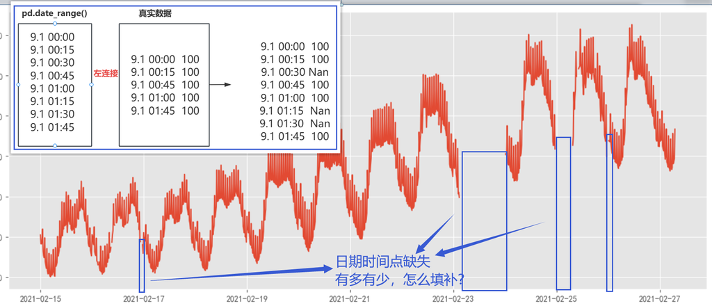

```python
# 因为是时序数据，判断缺失要看数据是否连续不间断
area_15min_date = pd.date_range(start='2018-01-01 00:00:00',
                                end='2021-08-31 23:45:00',freq='15min')  # 生成等差时间序列

area_15min_date = pd.DataFrame(area_15min_date, columns=['数据时间'])  # 转为数据框
# 数据合并，保留右表，右表是`大表`,大表表示数据量比较多的那个
area_15min = pd.merge(area_15min, area_15min_date,on='数据时间', how='right')
```

```python
area_15min.isna().sum() # 有缺失
```

```
数据时间           0
总有功功率（kw）    388
status       388
dtype: int64
```

```python
## status出现了缺失，先处理好， 1表示开关闭合处于正常状态
area_15min['status'] = area_15min['status'].fillna(1)
```

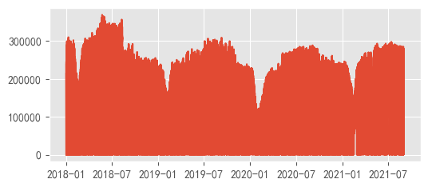

```python
# 绘制历年的用电总功率, 了解总功率变化情况，也就看个大概吧
plt.plot(area_15min['数据时间'], area_15min['总有功功率（kw）'])
plt.show()
```

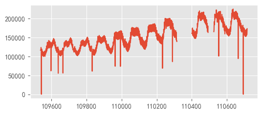

```
'排除检修情况，每天的用电量呈现周期性变化'
```

```python
# 取出‘2021-2’一整月的数据进行可视化
subset = area_15min[(area_15min['数据时间']>'2021-2-15')&(area_15min['数据时间']<'2021-2-28')]
plt.plot(subset['总有功功率（kw）'])
plt.show()
'''排除检修情况，每天的用电量呈现周期性变化'''
```

由上述结果可知，我们现有的数据不是连续的，故这里要进行缺失值处理

处理方法：

- 1、将缺失的时间段补上去
- 2、采用线性插值补齐、同日期插补、不同月份插补等

## 2.2 异常值检测（异常值想当做缺失值来处理）

- 异常值要将检修记录对应的数据排除掉

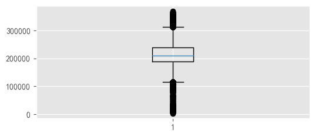

```
异常值个数： 7032
```

```python
# 使用箱型图的四方位居(IQR)对异常进行检测，也叫Tukey`s test
# fig = plt.boxplot(area_15min['总有功功率（kw）']) # 不能直接画，有缺失值出不来图
boxdata = area_15min.loc[area_15min['status']==1, :] # 排除
ind = boxdata['总有功功率（kw）'].isna()
fig = plt.boxplot(boxdata.loc[~ind, '总有功功率（kw）']) # 不能直接画，有缺失值出不来图
plt.show()

print('异常值个数：',len(fig['fliers'][0].get_ydata()))  # 获取异常值具体的值
```

一般使用IQR的1.5倍为标准:

- 值大于上四分位+1.5*IQR为异常值
- 值小于"下四分位-1.5*IQR"为异常值

```python
#
```

# 3. 数据预处理

## 3.1 异常值处理（变为缺失值进行处理）

```python
# 有进行工单处理的数据
gd_area_15min = area_15min[area_15min['status']!=1]
# 没有进行工单处理的数据
no_gd_area_15min = area_15min[area_15min['status']==1]
```

```python
# 定义判定异常值函数
# # 这里放宽条件，用2-3倍数，识别异常值，并用缺失值替代异常值
def clear_(x):
    QU = x.quantile(0.75)  # 上四分位数
    QL = x.quantile(0.25)  # 下四分位数
    IQR = QU - QL          # 四方位距 = 上四分位 - 下四分位
    x[(x>(QU+2.5*IQR)) | (x<(QL-2.5*IQR))] = None
    return x
```

```python
# 识别异常值，并用缺失值替代
no_gd_area_15min['总有功功率（kw）'] = no_gd_area_15min['总有功功率（kw）'].agg(clear_)
```

```python
no_gd_area_15min[no_gd_area_15min['总有功功率（kw）'].isna()].head()
```

|  | 数据时间 | 总有功功率（kw） | status |
| --- | --- | --- | --- |
| 13592 | 2018-05-22 14:00:00 | NaN | 1.0 |
| 13700 | 2018-05-23 17:00:00 | NaN | 1.0 |
| 13772 | 2018-05-24 11:00:00 | NaN | 1.0 |
| 13788 | 2018-05-24 15:00:00 | NaN | 1.0 |
| 13872 | 2018-05-25 12:00:00 | NaN | 1.0 |

```python
## 处理异常后拼接回来
area_15min = pd.concat([no_gd_area_15min, gd_area_15min], axis=0)
area_15min = area_15min.sort_values(by='数据时间')
```

```python
area_15min[area_15min['总有功功率（kw）'].isna()].head()
```

|  | 数据时间 | 总有功功率（kw） | status |
| --- | --- | --- | --- |
| 13592 | 2018-05-22 14:00:00 | NaN | 1.0 |
| 13700 | 2018-05-23 17:00:00 | NaN | 1.0 |
| 13772 | 2018-05-24 11:00:00 | NaN | 1.0 |
| 13788 | 2018-05-24 15:00:00 | NaN | 1.0 |
| 13872 | 2018-05-25 12:00:00 | NaN | 1.0 |

## 3.2 缺失值填补

```python
# 插值, only method='linear' is supported for DataFrame/Series
# 采用`最邻近插值`，一定时间段内，电功率变化不明显
area_15min['总有功功率（kw）2'] = area_15min['总有功功率（kw）'].interpolate(method='linear')
```

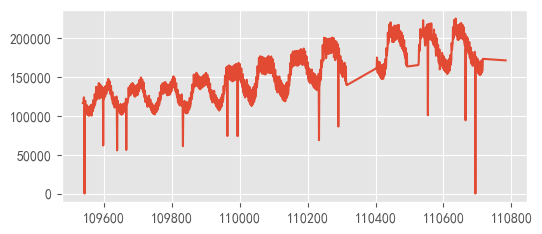

```python
# 取出‘2021-2’一整月的数据进行可视化
area_15min_ = area_15min[(area_15min['数据时间']>'2021-2-15')&(area_15min['数据时间']<'2021-2-28')]
plt.plot(area_15min_['总有功功率（kw）2'])
plt.show()
```

- 最邻近、线性插值等插值填充得到的效果不佳
- 优化空间：不同年份的同一时间段的用电量、前n后n法、不同月同一天的数据均值、同周期的相应时间点等
- 此处以相邻前后7天的数据做平均作为缺失值的代替

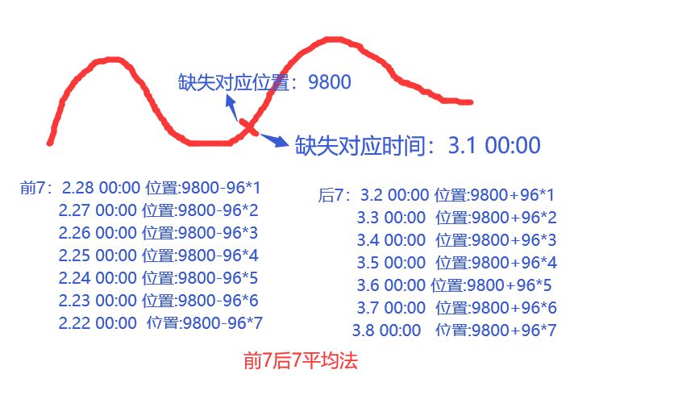

```python
k = 7 # 前后各取多少个值
isna = area_15min['总有功功率（kw）'].isnull()  # 取出哪些数据是缺失的
times = area_15min.loc[isna, '数据时间'] # 缺失的位置对应的时间点
times.head()
```

```
13592   2018-05-22 14:00:00
13700   2018-05-23 17:00:00
13772   2018-05-24 11:00:00
13788   2018-05-24 15:00:00
13872   2018-05-25 12:00:00
Name: 数据时间, dtype: datetime64[ns]
```

```python
'''缺失值处理方法： 找到缺少的点， 以这个点为基准，取它的前7天和后7天对应的时间点的数据求平均，
若前后不够7个，有多少个就取多少个， 再求平均'''
k = 7 # 前后各取多少个值
isna = area_15min['总有功功率（kw）'].isnull()  # 取出哪些数据是缺失的
times = area_15min.loc[isna, '数据时间'] # 缺失的位置对应的时间点
all_times = [str(i) for i in list(times)] # 把时间转为字符串
area_15min['总有功功率（kw）3'] = area_15min['总有功功率（kw）']  # 新增一列，用来存储填补之后的电量

for i in all_times: # 循环所有缺失的时间点
    ind = area_15min[area_15min['数据时间']==i].index.values[0] # # 找这个缺失的时间点在原始数据中哪个位置
    befor = [ind-96*j for j in range(k) if ind-96*j>0] # 前7天位置对应时间点的位置
    after = [ind+96*j for j in range(k) if ind+96*j<area_15min.shape[0]] # 后7天位置对应时间点的位置
    # 排除有检修的时间点
    all_index = [i for i in befor+after if i not in status_index]
    # 前7后7对应点电量求平均
    area_15min.loc[ind, '总有功功率（kw）3'] = area_15min.loc[all_index, '总有功功率（kw）'].mean()
    print(f'位置{ind}， 处理第{list(all_times).index(i)+1}-{len(all_times)}个缺失值, \
          {len(all_index)}个值替代缺失')
```

```
位置13592， 处理第1-611个缺失值,           14个值替代缺失
位置13700， 处理第2-611个缺失值,           14个值替代缺失
位置13772， 处理第3-611个缺失值,           14个值替代缺失
位置13788， 处理第4-611个缺失值,           14个值替代缺失
位置13872， 处理第5-611个缺失值,           14个值替代缺失
位置14180， 处理第6-611个缺失值,           14个值替代缺失
位置14360， 处理第7-611个缺失值,           14个值替代缺失
位置14544， 处理第8-611个缺失值,           14个值替代缺失
位置21293， 处理第9-611个缺失值,           14个值替代缺失
位置21294， 处理第10-611个缺失值,           14个值替代缺失
位置21295， 处理第11-611个缺失值,           14个值替代缺失
位置21297， 处理第12-611个缺失值,           14个值替代缺失
位置21299， 处理第13-611个缺失值,           14个值替代缺失
位置21301， 处理第14-611个缺失值,           13个值替代缺失
位置21302， 处理第15-611个缺失值,           13个值替代缺失
位置21303， 处理第16-611个缺失值,           14个值替代缺失
位置21305， 处理第17-611个缺失值,           14个值替代缺失
位置30498， 处理第18-611个缺失值,           13个值替代缺失
位置30669， 处理第19-611个缺失值,           14个值替代缺失
位置30873， 处理第20-611个缺失值,           14个值替代缺失
位置30874， 处理第21-611个缺失值,           14个值替代缺失
位置30878， 处理第22-611个缺失值,           14个值替代缺失
位置30879， 处理第23-611个缺失值,           14个值替代缺失
位置30881， 处理第24-611个缺失值,           14个值替代缺失
位置30882， 处理第25-611个缺失值,           14个值替代缺失
位置31981， 处理第26-611个缺失值,           13个值替代缺失
位置39521， 处理第27-611个缺失值,           14个值替代缺失
位置39522， 处理第28-611个缺失值,           14个值替代缺失
位置39523， 处理第29-611个缺失值,           14个值替代缺失
位置39525， 处理第30-611个缺失值,           14个值替代缺失
位置39526， 处理第31-611个缺失值,           14个值替代缺失
位置39527， 处理第32-611个缺失值,           14个值替代缺失
位置39529， 处理第33-611个缺失值,           13个值替代缺失
位置39530， 处理第34-611个缺失值,           14个值替代缺失
位置39531， 处理第35-611个缺失值,           14个值替代缺失
位置39533， 处理第36-611个缺失值,           14个值替代缺失
位置39534， 处理第37-611个缺失值,           14个值替代缺失
位置39537， 处理第38-611个缺失值,           13个值替代缺失
位置39538， 处理第39-611个缺失值,           14个值替代缺失
位置39539， 处理第40-611个缺失值,           14个值替代缺失
```

[output cut: 556 more lines]

```
位置126357， 处理第597-611个缺失值,           14个值替代缺失
位置126358， 处理第598-611个缺失值,           14个值替代缺失
位置126359， 处理第599-611个缺失值,           13个值替代缺失
位置126360， 处理第600-611个缺失值,           14个值替代缺失
位置126361， 处理第601-611个缺失值,           12个值替代缺失
位置126362， 处理第602-611个缺失值,           14个值替代缺失
位置126363， 处理第603-611个缺失值,           14个值替代缺失
位置126364， 处理第604-611个缺失值,           14个值替代缺失
位置126365， 处理第605-611个缺失值,           14个值替代缺失
位置126366， 处理第606-611个缺失值,           14个值替代缺失
位置126367， 处理第607-611个缺失值,           13个值替代缺失
位置126368， 处理第608-611个缺失值,           14个值替代缺失
位置126369， 处理第609-611个缺失值,           14个值替代缺失
位置126370， 处理第610-611个缺失值,           14个值替代缺失
位置126371， 处理第611-611个缺失值,           14个值替代缺失
```

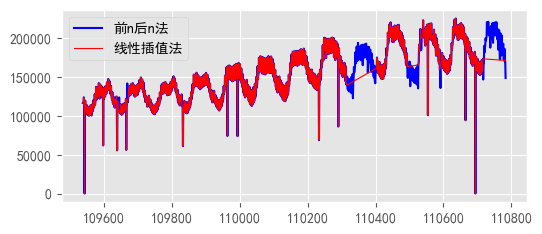

```python
# 取出‘2021-2’一整月的数据进行可视化
area_15min_ = area_15min[(area_15min['数据时间']>'2021-2-15')&(area_15min['数据时间']<'2021-2-28')]
plt.plot(area_15min_['总有功功率（kw）3'], c='b')
plt.plot(area_15min_['总有功功率（kw）2'], c='r', lw=0.8)
plt.legend(['前n后n法','线性插值法'])
plt.show()
```

```python
area_15min.insert(loc=1, column='总有功功率', value=area_15min['总有功功率（kw）3'])
```

```python
area_15min.drop(['总有功功率（kw）','总有功功率（kw）2','总有功功率（kw）3'], axis=1, inplace=True)
```

```python
area_15min.columns
```

```
Index(['数据时间', '总有功功率', 'status'], dtype='object')
```

# 4. 特征工程

## 4.1 日期与总功率之间的关系

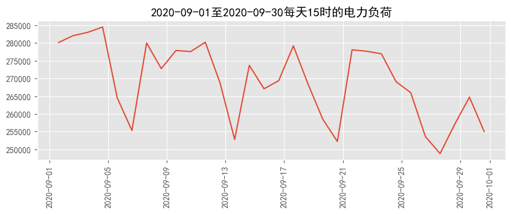

```python
# 每日与总有功功率之间关系
kw_d = pd.date_range(start='2020/9/1 15:00:00',
                     end='2020/9/30 15:45:00',freq='24h')
kw_d = pd.DataFrame(kw_d,columns=['数据时间'])
kw_d = pd.merge(area_15min, kw_d,on='数据时间',how='inner').sort_values(by='数据时间')  # 数据合并，并按时间排序

plt.figure(figsize=(10,3))
plt.plot(kw_d['数据时间'], kw_d['总有功功率'])
plt.title('2020-09-01至2020-09-30每天15时的电力负荷')
plt.xticks(rotation=90)
plt.show()
```

- 可以发现每日总功率变化呈现周期性，每个中周期的末尾呈现突降，推测为周末的原因，进而可体现出工作日与总功率的变化关系。

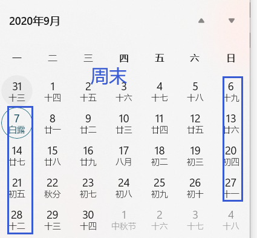

## 4.2 时刻与总功率之间的关系

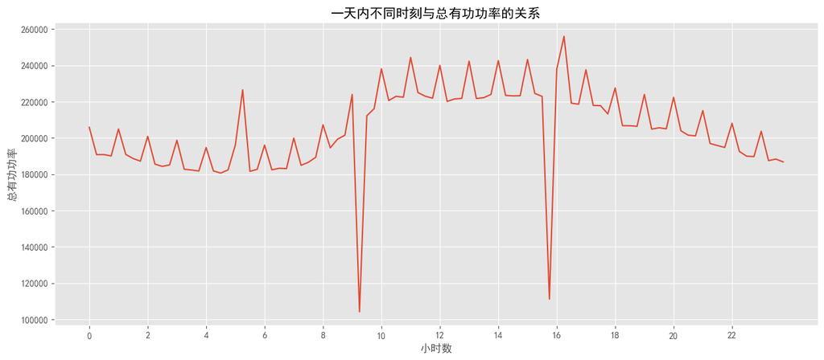

```python
# 绘制一天内不同时刻与总有功功率的关系
kw_h = pd.date_range(start='2019/9/1 00:00:00', end='2019/9/1 23:45:00',freq='15min')
kw_h = pd.DataFrame(kw_h,columns=['数据时间'])
kw_h = pd.merge(area_15min, kw_h, on='数据时间', how='right').sort_values(by='数据时间')  # 数据合并，并按时间排序

plt.figure(figsize=(15,6))
plt.plot(kw_h['数据时间'], kw_h['总有功功率'])
plt.xticks(kw_h.iloc[::8,0],kw_h.iloc[::8,0].dt.hour)
plt.xlabel('小时数')
plt.ylabel('总有功功率')
plt.title('一天内不同时刻与总有功功率的关系')
plt.show()
```

- 可以发现早晨 5 点开始负荷持续增大，直到上午 11 时达到高峰，而后中午 12时左右小幅度降低后，午后又开始增大，大约 17 时之后开始下降，夜晚的负荷明显处于全天的最低时段。
- 需预测未来10天间隔15分钟的电力负荷值，所给气象数据是每日的值，故建模时暂不考虑气象数据。
- 根据前文分析，负荷数据具有明显的周期性，故提取数据的日期特征以体现周期规律，包括“年”“月”“日”“小时”“分钟”“星期”“季度”“是否周末”等 **暂不考虑节假日的影响**
- 再纳入历史电力负荷的影响，取前n天（或前n个点）的负荷与日期特征一起作为输入特征，共同预测下一个时刻的电力负荷值。所有数据需要经过标准化处理，以消除不同量纲带来的影响，提高建模运行时的速度

## 4.3 时间特征提取

```python
# area_15min['年份'] = area_15min['数据时间'].dt.year      # 年份
area_15min['月'] = area_15min['数据时间'].dt.month     # 月
area_15min['日'] = area_15min['数据时间'].dt.day         # 日
area_15min['小时'] = area_15min['数据时间'].dt.hour      # 小时
# area_15min['分钟'] = area_15min['数据时间'].dt.minute      # 分钟
area_15min['星期'] = area_15min['数据时间'].dt.weekday   # 0-6，0为周一
# area_15min['季度'] = area_15min['数据时间'].dt.quarter   # 季度
area_15min['是否为工作日'] = area_15min['数据时间'].apply(is_workday).astype(int)  # 1工作日，0为假期

'''也可以添加其他特征进来，比如： area_15min['天气']=0000000等， 直接添加列就行'''
```

```
"也可以添加其他特征进来，比如： area_15min['天气']=0000000等， 直接添加列就行"
```

```python
area_15min.head(2)
```

|  | 数据时间 | 总有功功率 | status | 月 | 日 | 小时 | 星期 | 是否为工作日 |
| --- | --- | --- | --- | --- | --- | --- | --- | --- |
| 0 | 2018-01-01 00:00:00 | 244033.7682 | 1.0 | 1 | 1 | 0 | 0 | 0 |
| 1 | 2018-01-01 00:15:00 | 232720.6402 | 1.0 | 1 | 1 | 0 | 0 | 0 |

```python
# 中间数据保存
area_15min.to_csv('./data/area_15min.csv', index=None, encoding='utf-8')
```

# 5. 模型构建

## 5.1 划分数据集

```python
area_15min.shape[0]/96/360 # 共3年多的数据
```

```
3.7194444444444446
```

```python
# 留出数据自己做测试
days = 10
train = area_15min.iloc[:-96*days,1:]  # 训练集
test = area_15min.iloc[-96*days:,1:]   # 测试集
train.reset_index(drop=True, inplace=True)
test.reset_index(drop=True, inplace=True)
print(train.shape, test.shape)
```

```
(127584, 7) (960, 7)
```

```python
train.columns
```

```
Index(['总有功功率', 'status', '月', '日', '小时', '星期', '是否为工作日'], dtype='object')
```

## 5.2 数据标准化

```python
# 标准化
from sklearn.preprocessing import MinMaxScaler
mm = MinMaxScaler()
mm_train = mm.fit_transform(train)
mm_test = mm.transform(test)
```

## 5.3 构造滚动预测的数据

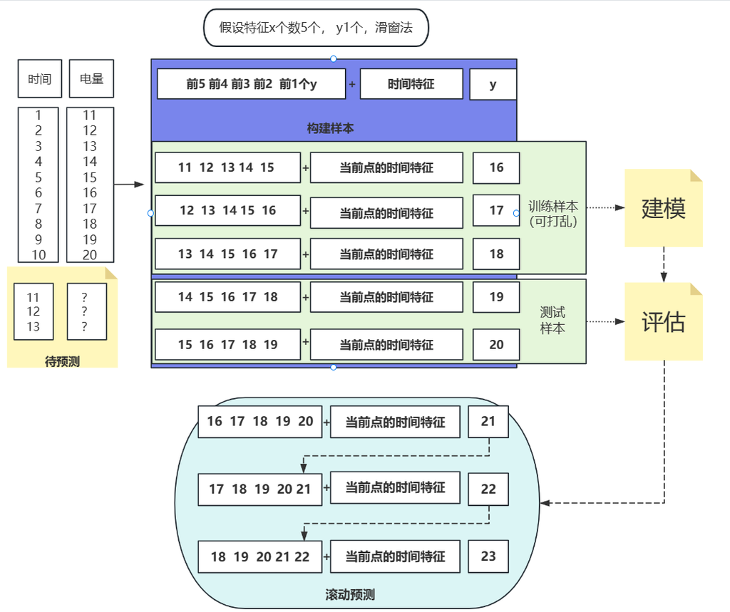

```python
# 通过滑动窗口来构建类似于特征x和标签y，使用前96个时间点的数据预测下一个时间点
# 初次之外，加上时间特征、前7天对应时间点特征、 前14天对应时间点特征、前30、60、90等
import numpy as np
from tqdm import tqdm
def dataset(data,  win_size = 96):
    ''':params: data,表示标准化之后的除电量外的其他特征，例如时间特征、天气特征
       :params: y,表示原始的y（用原始的y是因为要用标准化后的特征，直接预测原始的y）
       :params: bzh_y，表示标准化之后的y
       :params: win_size，表示滑窗大小，需要用前面多个天的电量做特征
    '''
    X = []
    Y = []
    for i in tqdm(range(len(data))):
        try: # 拿不到数据会报错，直接跳过
            temp_x = data[i:i + win_size, 0].tolist() # 前win_size个电量做特征x
            temp_x.extend( data[win_size+i,1:].tolist()) # 拼接其他特征
            temp_y = data[i + win_size, 0]   # 后1个做标签y
            X.append(temp_x)
            Y.append(temp_y)
        except:
            pass
    X = np.asarray(X)
    Y = np.asarray(Y)
    return X, Y

# 前96*n个点(n天)的数据做特征， 特征太多模型跑不动就减少，取四分之一天、半天、1天
win_size = int(96*2)
train_x, train_y = dataset(mm_train, win_size=win_size)
train_x.shape, train_y.shape
```

```
((127392, 198), (127392,))
```

## 5.4 数据建模

- 数据量大，特征多时交叉验证和调参耗时，因此省去这两部分。
- 在时间序列回归问题上，随机森林和XGB算法应用效果是较好的，直接选取随机森林进行建模。

```python
from sklearn.model_selection import train_test_split

# 数据集划分,保留n天数据作为测试
n = 100
X_train, X_val, y_train, y_val = train_test_split(train_x, train_y,
                                                    test_size=96*n,
                                                    shuffle=True)
```

```python
from sklearn.ensemble import RandomForestRegressor
xgb_model = RandomForestRegressor(n_estimators=50, max_depth=50, verbose=0, n_jobs=-1)
xgb_model.fit(X_train, y_train)
```

```
RandomForestRegressor(max_depth=50, n_estimators=50, n_jobs=-1)
```

```python
pred = xgb_model.predict(X_val)
from sklearn.metrics import mean_absolute_error,mean_absolute_percentage_error,r2_score
print("mae：",mean_absolute_error(y_val, pred))
print("mape",mean_absolute_percentage_error(y_val, pred))
print("r2：",r2_score(y_val, pred))
```

```
mae： 0.007382957380947593
mape 13490281299.596893
r2： 0.9842260953302621
```

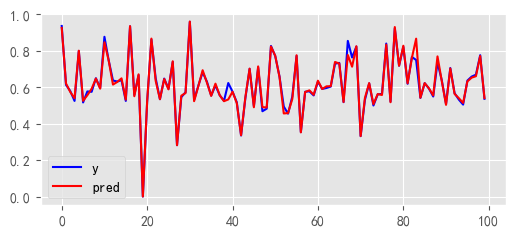

```python
import matplotlib.pyplot as plt
# 模型测试结果比较
plt.plot(y_val[:100], c= 'b')
plt.plot(pred[:100], c= 'r')
plt.legend(['y','pred'])
plt.show()
```

## 5.5 模型评估

```python
# 以已知的最后一天作为基准
from tqdm import tqdm
last_data_dl = list(train_x[-1, :win_size])  # 最后一次的电量特征

predy = [] # 预测的结果放这~
for i in tqdm(range(96*days)): # 预测n天，则循环预测96*n次
    if i==0: # i==0表示用已知的训练数据预测未来的第一个点
        last_data_dl.append(train_y[-1]) # 添加下一天的预测结果
    else: # i！=0 表示继续迭代预测，用上一次预测的结果y当做新的特征值
        last_data_dl.append(predi) # 添加下一天的预测结果
    last_data_dl = last_data_dl[1:] # 删除第一个电量特征
    last_data_featrue = list(mm_test[i, 1:]) # 时间特征替换成新的
    last_data = last_data_dl + last_data_featrue # 删除前一天的特征,时间特征替换成新的
    test_data = np.array([last_data])
    predi = xgb_model.predict(test_data)[0] # 继续预测
    predy.append(predi)
```

```python
## 还原真实值
pred_df = pd.DataFrame(predy).values.repeat(train.shape[1]).reshape(96*days, train.shape[1])
pred_df = mm.inverse_transform(pred_df) # 还原真实y值
pred_df.shape
```

```
(960, 7)
```

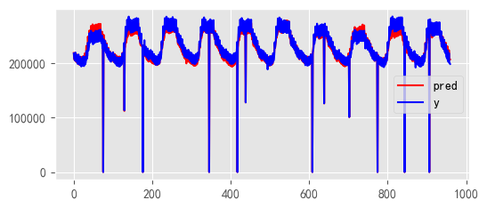

```python
# 预测未来的情况
my_pred = pred_df[:, 0]
plt.plot(my_pred, c='r')
plt.plot(test['总有功功率'], c='b')
plt.legend(['pred','y'])
```

```python
print("mae：",mean_absolute_error(test['总有功功率'], my_pred))
print("mape",mean_absolute_percentage_error(test['总有功功率'], my_pred))
print("r2：",r2_score(test['总有功功率'], my_pred))
```

```
mae： 4342.7124538714825
mape 0.018401891757181314
r2： 0.9717956292804375
```

```python
'''模型通过，可以使用这个模型进行数据预测'''
```

```
'模型通过，可以使用这个模型进行数据预测'
```

# 模型应用（滚动预测）

## 6.1 数据整理

```python
# 数据读取
test_min_15 = pd.read_csv('./data/附件1-区域15分钟负荷预测数据.csv',
                     encoding='gbk', parse_dates=['数据时间\t'])
test_min_15 = test_min_15.rename(columns={'数据时间\t':'数据时间'})
```

```python
def feature_extract(data):
#     data['年份'] = data['数据时间'].dt.year      # 年份
    data['月'] = data['数据时间'].dt.month     # 月
    data['日'] = data['数据时间'].dt.day         # 日
    data['小时'] = data['数据时间'].dt.hour      # 小时
#     data['分钟'] = data['数据时间'].dt.minute      # 分钟
    data['星期'] = data['数据时间'].dt.weekday   # 0-6，0为周一
#     data['季度'] = data['数据时间'].dt.quarter   # 季度
    data['是否为工作日'] = data['数据时间'].apply(is_workday).astype(int)  # 1工作日，0为假期
    return data
```

```python
# 构建时间特征
test_min_15 = feature_extract(test_min_15)
test_min_15.head()
```

|  | 数据时间 | 总有功功率（kw） | 月 | 日 | 小时 | 星期 | 是否为工作日 |
| --- | --- | --- | --- | --- | --- | --- | --- |
| 0 | 2021-09-01 00:00:00 | NaN | 9 | 1 | 0 | 2 | 1 |
| 1 | 2021-09-01 00:15:00 | NaN | 9 | 1 | 0 | 2 | 1 |
| 2 | 2021-09-01 00:30:00 | NaN | 9 | 1 | 0 | 2 | 1 |
| 3 | 2021-09-01 00:45:00 | NaN | 9 | 1 | 0 | 2 | 1 |
| 4 | 2021-09-01 01:00:00 | NaN | 9 | 1 | 1 | 2 | 1 |

## 6.2 添加工单信息

```python
with open('./data/附件3：工单_test.txt', encoding='GBK', mode='r') as f:
    gd_test = f.readlines()

# 提取时间写法不一致的数据
[i for i in gd_test if '点' in i or '分' in i or '时,' in i or '时，' in i or '日' in i or '年' in i ]
```

```
[]
```

```python
# 处理【5点半】类的数据
gd_test = [i.replace('点半','点30') for i in gd_test ]

# 提取所有时间数值
gd_test_time_str = [re.findall('[0-9]+',i) for i in gd_test]
gd_test_time_str = [i+['00']*3 for i in gd_test_time_str]

# 处理成时间的字符串
gd_test_time = [f'{i[0]}-{i[1]}-{i[2]} {i[3]}:{i[4]}:{i[5]}' for i in gd_test_time_str]
print(gd_test_time[:3])

# 转为时间格式
gd_test_time = pd.to_datetime(pd.Series(gd_test_time))
```

```
['2021-09-02 05:15:00', '2021-09-02 21:30:00', '2021-09-03 12:00:00']
```

```python
# 提取开关状态
kg_test_status = [i.replace(':','：').split('开关状态：')[-1].replace('\n','') for i in gd_test ]
print(set(kg_test_status))

# 由数据可知， 开==全开, 用0表示全部打开， 0.5表示半开
kg_test_status = list(map(lambda x: 0.5 if x=='半开' else 0,  kg_test_status))
set(kg_status)
```

```
{'半开', '全开'}
```

```
{0, 0.5}
```

```python
gd_test_data = pd.DataFrame({'数据时间':gd_test_time, 'status':kg_test_status})
gd_test_data.head(3)
```

|  | 数据时间 | status |
| --- | --- | --- |
| 0 | 2021-09-02 05:15:00 | 0.0 |
| 1 | 2021-09-02 21:30:00 | 0.5 |
| 2 | 2021-09-03 12:00:00 | 0.5 |

```python
## 拼接工单数据
test_min_15 = pd.merge(test_min_15, gd_test_data, how='left', on='数据时间')
# 用1表示开关闭合
test_min_15['status'] = test_min_15['status'].fillna(1)
test_min_15.rename(columns={'总有功功率（kw）':'总有功功率'}, inplace=True)
test_min_15.head(5)
```

|  | 数据时间 | 总有功功率 | 月 | 日 | 小时 | 星期 | 是否为工作日 | status |
| --- | --- | --- | --- | --- | --- | --- | --- | --- |
| 0 | 2021-09-01 00:00:00 | NaN | 9 | 1 | 0 | 2 | 1 | 1.0 |
| 1 | 2021-09-01 00:15:00 | NaN | 9 | 1 | 0 | 2 | 1 | 1.0 |
| 2 | 2021-09-01 00:30:00 | NaN | 9 | 1 | 0 | 2 | 1 | 1.0 |
| 3 | 2021-09-01 00:45:00 | NaN | 9 | 1 | 0 | 2 | 1 | 1.0 |
| 4 | 2021-09-01 01:00:00 | NaN | 9 | 1 | 1 | 2 | 1 | 1.0 |

## 6.3 数据处理

```python
# 取历史数据，历史数据构造成x,y(目的是得到最后一条数据预测未来的第一个)
history = area_15min[ train.columns]
history = mm.transform(history)

# 构造数据，相当于更新更多的历史数据，用来重新训练模型（若是离线模型，训练好的模型可以不用每次都重新训练）
hisx, histy = dataset(history,  win_size=win_size)
hisx.shape, histy.shape
```

```
((128352, 198), (128352,))
```

```python
mm_test_min_15 = mm.transform(test_min_15[train.columns])
mm_test_min_15.shape
```

```
(960, 7)
```

## 6.4 预测未来十天间隔十五分钟的负荷

```python
## 验证模型可用和调参后，可以拿全部数据跑一遍模型
# xgb_model = RandomForestRegressor(n_estimators=100, max_depth=35, verbose=0, n_jobs=-1)
# xgb_model.fit(hisx, histy)
```

```python
# 以已知的最后一天作为基准
from tqdm import tqdm
last_data_dl = list(hisx[-1, :win_size])  # 最后一次的电量特征

predy = [] # 预测的结果放这~
for i in tqdm(range(96*days)): # 预测n天，则循环预测96*n次
    if i==0: # i==0表示用已知的训练数据预测未来的第一个点
        last_data_dl.append(histy[-1]) # 添加下一天的预测结果
    else: # i！=0 表示继续迭代预测，用上一次预测的结果y当做新的特征值
        last_data_dl.append(predi) # 添加下一天的预测结果
    last_data_dl = last_data_dl[1:] # 删除第一个电量特征
    last_data_featrue = list(mm_test_min_15[i, 1:]) # 时间特征替换成新的
    last_data = last_data_dl + last_data_featrue # 删除前一天的特征,时间特征替换成新的
    test_data = np.array([last_data]) # 转化格式： (1行 * N列)
    predi = xgb_model.predict(test_data)[0] # 继续预测
    predy.append(predi)
```

```python
## 还原真实值
pred_df = pd.DataFrame(predy).values.repeat(train.shape[1]).reshape(96*days, train.shape[1])
pred_df = mm.inverse_transform(pred_df) # 还原真实y值
pred_df.shape
```

```
(960, 7)
```

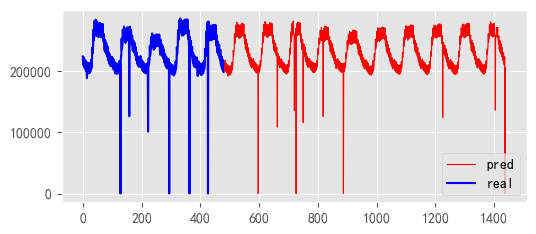

```
'比较预测前后的结果，不要光看训练和测试的指标，不一定有用；\n   预测结果明显不符合规律或整体偏大偏小都是有问题的\n'
```

```python
### 绘图查看预测的结果
my_pred = list(pred_df[:, 0])
plt.plot(list(area_15min['总有功功率'] )[-96*5:]+my_pred, c='r', label='pred', lw=0.8)
plt.plot(list(area_15min['总有功功率'] )[-96*5:], c='b', label='real', lw=1.5)
plt.legend()
plt.show()
'''比较预测前后的结果，不要光看训练和测试的指标，不一定有用；
   预测结果明显不符合规律或整体偏大偏小都是有问题的
'''
```

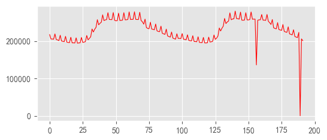

```python
# 画出两天的情况看看，基本负荷日周期
plt.plot(my_pred[-96*2:], c='r', label='pred', lw=0.8)
```

```python
# 将预测得到的功率放到`附件1.1-区域15分钟负荷预测数据.csv`
min_15 = pd.read_csv('./data/附件1-区域15分钟负荷预测数据.csv',
                     encoding='gbk', parse_dates=['数据时间\t'])
min_15 = min_15.rename(columns={'数据时间\t':'数据时间'})
min_15['总有功功率（kw）'] = my_pred
```

```python
# # 数据结果保存即可
# min_15.to_csv('./data/负荷预测结果数据.csv', index=None, encoding='gbk')
```

## 6.5 未来10天日负荷的最大值和最小值

```python
# 取出日负荷的最大值和最小值
min_15['date'] = min_15['数据时间'].dt.date
max_min = min_15[test_min_15['status']==1].groupby(by='date')['总有功功率（kw）'].agg( [max, min]) # 排除检修的数据
# max_min = min_15.groupby(by='date')['总有功功率（kw）'].agg( [max, min]) # 不排除检修的数据
max_min.reset_index(drop=False, inplace=True)
```

```python
max_min.head()
```

|  | date | max | min |
| --- | --- | --- | --- |
| 0 | 2021-09-01 | 279708.103458 | 191977.949718 |
| 1 | 2021-09-02 | 280757.520678 | 195536.931564 |
| 2 | 2021-09-03 | 281613.573384 | 195089.503862 |
| 3 | 2021-09-04 | 273120.254894 | 197258.334760 |
| 4 | 2021-09-05 | 266982.533104 | 198166.920100 |

```python
df1 = pd.merge(left=max_min[['date','max']], right=min_15,
         left_on=['date', 'max'], right_on=['date', '总有功功率（kw）'],
         how='left')
df1.columns = ['日期', '最大负荷', '最大负荷时间', 'y1']

df2 = pd.merge(left=max_min[['date','min']], right=min_15,
         left_on=['date', 'min'], right_on=['date', '总有功功率（kw）'],
         how='left')
df2.columns = ['日期', '最小负荷', '最小负荷时间', 'y2']
result = pd.concat([df1[['日期','最大负荷', '最大负荷时间']],
                df2[['最小负荷', '最小负荷时间']]],
              axis=1)
result
```

|  | 日期 | 最大负荷 | 最大负荷时间 | 最小负荷 | 最小负荷时间 |
| --- | --- | --- | --- | --- | --- |
| 0 | 2021-09-01 | 279708.103458 | 2021-09-01 11:00:00 | 191977.949718 | 2021-09-01 03:30:00 |
| 1 | 2021-09-02 | 280757.520678 | 2021-09-02 11:00:00 | 195536.931564 | 2021-09-02 05:45:00 |
| 2 | 2021-09-03 | 281613.573384 | 2021-09-03 11:00:00 | 195089.503862 | 2021-09-03 05:15:00 |
| 3 | 2021-09-04 | 273120.254894 | 2021-09-04 14:00:00 | 197258.334760 | 2021-09-04 04:30:00 |
| 4 | 2021-09-05 | 266982.533104 | 2021-09-05 14:00:00 | 198166.920100 | 2021-09-05 04:15:00 |
| 5 | 2021-09-06 | 271438.134674 | 2021-09-06 15:00:00 | 192950.802282 | 2021-09-06 05:30:00 |
| 6 | 2021-09-07 | 275256.427318 | 2021-09-07 15:00:00 | 194713.709154 | 2021-09-07 05:15:00 |
| 7 | 2021-09-08 | 276995.390868 | 2021-09-08 15:00:00 | 194454.297402 | 2021-09-08 05:15:00 |
| 8 | 2021-09-09 | 278285.843860 | 2021-09-09 16:00:00 | 194278.276664 | 2021-09-09 05:15:00 |
| 9 | 2021-09-10 | 280204.391458 | 2021-09-10 11:00:00 | 194929.676812 | 2021-09-10 05:15:00 |

```python
# 预测出的最大负荷在中午或下午， 最小负荷在凌晨5点左右
```

```python
# # 数据保存
# result.to_csv('./data/每天最大最小负荷预测数据.csv', encoding='utf-8', index=None)
```

# 7 改进空间

1. 特征构建，可以加上其他特征，例如：当前点的同周期其他特征
2. 缺失、异常的处理可以换种方式
3. 特征可以再做筛选，丢弃一些噪声
4. 模型调参
5. 模型可以尝试交叉验证使用其他模型，或者模型融合、或者深度模型